# Spiny Lobster Abundance in California

Janelle Christensen & Lauren Manzo

11/18/2019

### Introduction

The California Spiny Lobster (*panulirus interruptus*) is an important species in the kelp forests in California. Lobsters are a vital predator of kelp-eating sea urchins. Without predation, sea urchins have the ability to demolish kelp forests and create urchin barrens, destroying the ecological diversity that kelp forests create. The benefits of spiny lobsters for kelp forests has been widely studied and monitoring their abundance in these ecosystems is crucial to maintain them (Foster and Schiel 2010).

The Santa Barbara Channel Long Term Ecological Research (SBC LTER) has been monitoring the abundance of fish, invertebrates and algae in five sites from the Santa Barbara channel since 2001. They then started gathering data on spiny lobster abundance in 2012. In January 2012, two of the five sites, Isla Vista and Naples, were designated Marine Protected Areas (MPA).

We will use the collected data to compare the differences in sites that are Marine Protected Areas and non-Marine Protected Areas between 2012 - 2018. Marine Protected areas provide a unique ability to monitor the growth of abundance in spiny lobsters due to the restrictions on fishing in these areas.

Figure 1. The Santa Barbara Chanel Long Term Ecological Research (SBC LTER)

[figure not shown]

Credit: [SBC LTER](https://portal.lternet.edu/nis/mapbrowse?packageid=knb-lter-sbc.77.3)

Figure 2. California Spiny Lobster

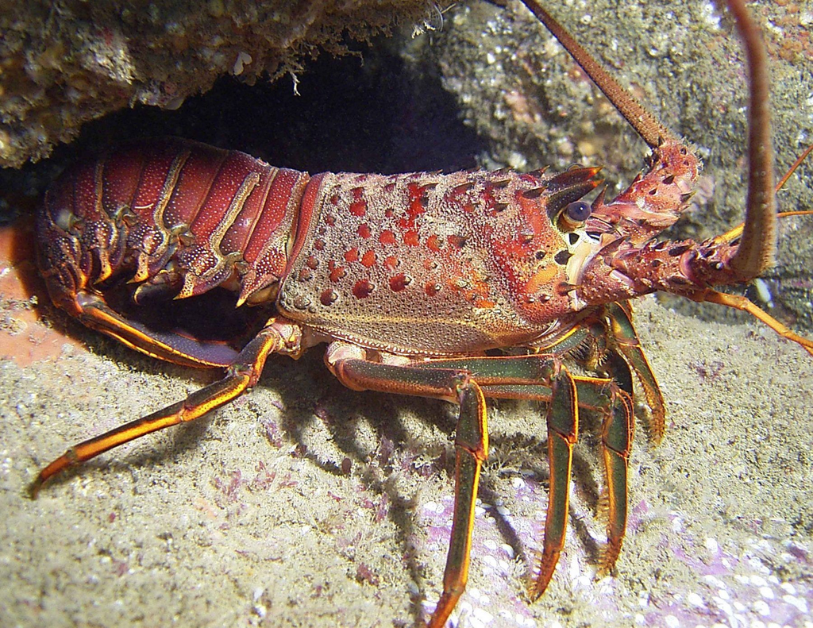

Credit: [Catalina Island Marine Institute](https://cimioutdoored.org/wp-content/uploads/2017/09/California-Spiny-Lobster.jpg)

### Data and Methods

Data for this project was collected from 2012 - 2018 by the Santa Barbara Channel Long Term Ecological Research team. Lobster numbers and sizes were collected by divers at five sites, including two Marine Protected Areas (Naples and Isla Vista) and three Non-Marine Protected Areas (Arroyo Quemado, Mohawk and Carpinteria). All the samples were gathered in the late summer before the start of the fishing season. All the data was gathered in four 300m<sup>2</sup> area (60m x 5m) lobster transects. Trends in Marine Protected Areas were compared with trends in Non-Marine protected Areas. All data was analyzed and put into figures through the software R version 3.6.1.

### Results

##### 1. Observed annual lobster abundance at the five sites over time

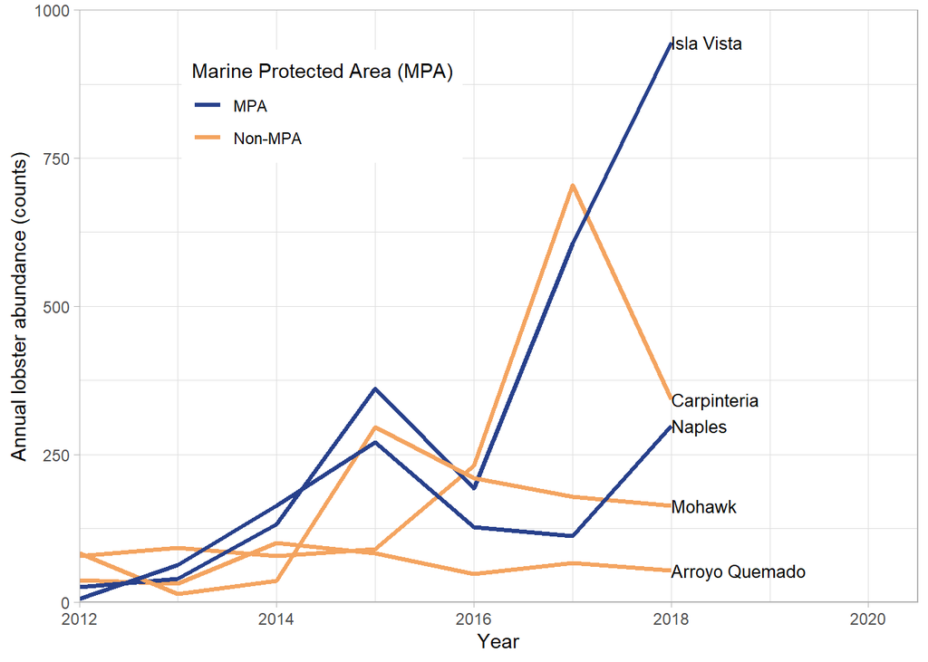

Figure 3: Annual lobster abundance observed from 2012 - 2018 in five sites that were either Marine Protected (dark blue) or Non-Marine Protected Areas (light orange) in the Santa Barbara Channel. Marine Protected Areas showed change in lobster abundance over the sampling period. Data: SBC LTER

##### 2. Lobster size distribution shifts in each site between the years 2012 and 2018

Lobster sizes in the three Non-Marine Protected Areas were observed to have less than noticeable shifts in lobster sizes. While lobster sizes in Marine Protected Areas did have noticeable shifts.

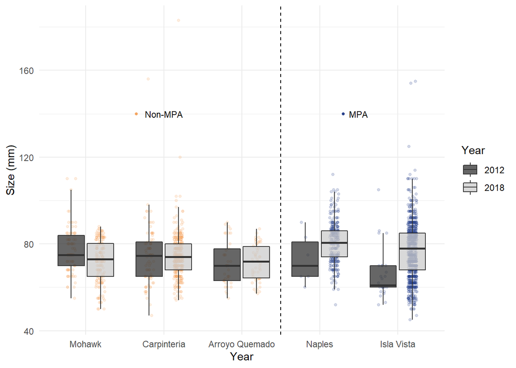

Figure 4: Lobster sizes observed from 2012 and 2018 by dive surveys in five sites that were either Marine Protected (dark blue) or Non-Marine Protected Areas (light orange) in the Santa Barbara Channel. Marine Protected Areas showed change in lobster size over the sampling period. Dashed line is seperating Marine Protected Areas and Non-Marine Protected Areas. Data: SBC LTER

##### 3. Mean lobster sizes at Marine Protected Areas vs. Non-Marine Protected Areas

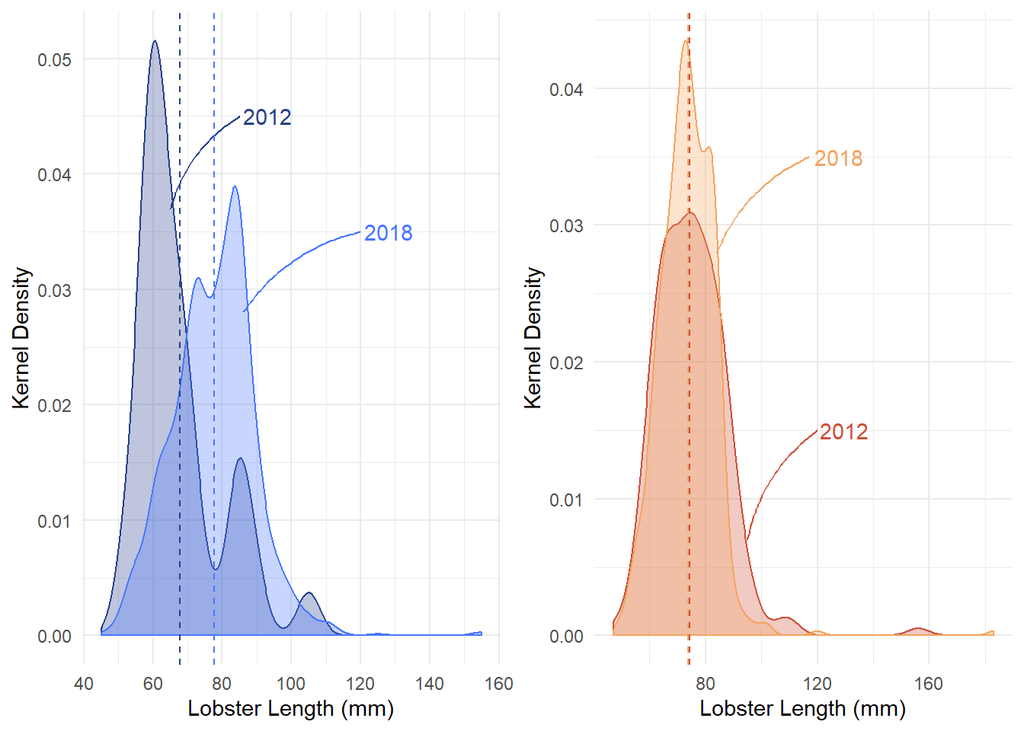

Figure 5: Lobster size in Marine Protectd Areas and Non-Marine Protected Areas in 2012 and 2018 kernal density for mean lobster size in Marine Protected Areas in 2012 (dark blue) and 2018 (light blue) and Non-Marine Protected Areas in 2012 (dark orange) and 2018 (light orange). The means are shown as dashed lines. Data: SBC LTER

Figure 6. The mean, standard deviation, and sample sizes of lobsters observed in Marine Protected Areas and Non-Marine Protected Areas in 2012 and 2018.

| Statistics of Lobsters in the Santa Barbara Channel Marine Protected Area (MPA) | Statistics of Lobsters in the Santa Barbara Channel Year | Statistics of Lobsters in the Santa Barbara Channel Mean Lobster Size (mm) | Statistics of Lobsters in the Santa Barbara Channel Standard Deviation of Lobster Size | Statistics of Lobsters in the Santa Barbara Channel Number of Lobsters |
| --- | --- | --- | --- | --- |
| MPA | 2012 | 67.38 | 12.15 | 32 |
| MPA | 2018 | 77.57 | 11.70 | 1244 |
| Non-MPA | 2012 | 74.92 | 12.41 | 199 |
| Non-MPA | 2018 | 73.62 | 10.09 | 561 |

Mean lobster size increased significantly overall in Marine Protected Areas. While the mean lobster size did not significantly increase in Non-Marine Protected Areas.

For the two Marine protected areas, comparing the means between 2012 and 2018 (n = 1276), the mean for 2012 is 67.38 $\pm$ 12.15, and the mean for 2018 is 77.57 $\pm$ 11.7 with an actual difference in mean size between the two years being 10.19 (two-sided t-test, t(32.5) = -4.69, p < 0.001) with an effect size of 0.87. This shows significant increase in mean lobster size between 2012 and 2018 in Marine Protected Areas.

For 2012, between Marine Protected Areas and Non-Marine Protected Areas, with an actual difference in mean size between the two areas being 7.55 (two-sided t-test, t(42.09) = -3.25, p = 0.002 with an effect size of 0.61. This shows significant difference in mean lobster size in 2012 between Marine Protected Areas and Non-Marine Protected Areas.

For 2018, between Marine Protected Areas and Non-Marine Protected Areas, with an actual difference in mean size between the two areas being 3.95 (two - sided t-test t(1239.51) = 7.31, p < 0.001 with an effect size of 0.35. This shows significant difference in mean lobster size in 2018 between Marine Protected Areas and Non-Marine Protected Areas.

#### Summary

- Making sites Marine Protected Areas creates greater increases in lobster abundance and size (Figure 3 and 5).
- Lobster size increased more in the two Marine Protected Areas than in the three Non-Marine Protected Areas (Figure 4).
- Mean lobster size increased significantly overall in Marine Protected Areas and mean lobster size did not significantly increase in Non-Marine Protected Areas. Mean lobster size grew by 10.19 mm in Marine Protected areas whereas they decreased by 1.3 mm in Non-Marine Protected Areas (Figure 5 and 6).

#### References

**Foster, Michael S., and David R. Schiel.** “Loss of Predators and the Collapse of Southern California Kelp Forests: Alternatives, Explanations and Generalizations.” Journal of Experimental Marine Biology and Ecology, vol. 393, no. 1-2, 2010, pp. 59–70., doi:10.1016/j.jembe.2010.07.002.

**Reed D. 2019.** SBC LTER: Reef: Abundance, size and fishing effort for California Spiny Lobster (Panulirus interruptus), ongoing since 2012. Environmental Data Initiative. https://doi.org/10.6073/pasta/a593a675d644fdefb736750b291579a0. Dataset accessed 11/17/2019.